[figure not shown]

# Exploración y análisis espacial de especies tropicales en un área geográfica utilizando el GBIF y Python

En este artículo exploraremos el fascinante mundo de las especies tropicales y cómo podemos realizar un análisis espacial de ellas en un área geográfica específica. Para ello, utilizaremos el GBIF (Global Biodiversity Information Facility) y aprovecharemos las valiosas bases de datos de universidades y otras instituciones.

Descubriremos cómo el uso de lenguajes de programación como Python puede brindarnos ventajas significativas para proyectos ambientales, permitiéndonos visualizar y analizar de manera eficiente grandes conjuntos de datos.

**¡Acompáñanos en esta exploración y análisis de especies tropicales!**

Nuestro ejercicio tiene 4 partes

- **Parte 1**: Introducción y preparación de datos
- **Parte 2**: Análisis y visualización espacial
- **Parte 3**: Cálculo del rectángulo mínimo
- **Parte 4**: Búsqueda de especies

## **Parte 1**: Introducción y preparación de datos

```python
# Importamos las librerias
import pandas as pd
import geopandas as gpd
import numpy as np
import matplotlib.pyplot as plt
from pygbif import species, occurrences
from shapely.geometry import Point, Polygon
import time
import tempfile
import zipfile
import os
import requests
import fuzzywuzzy.fuzz as fuzz
```

```python
# Ajustamos el directorio de trabajo
#os.chdir("C:\\Users\\Acer")
```

Importamos los datos geograficos

```python
# Obtenemos la URL para descargar los datos
url = 'https://data.humdata.org/dataset/50ea7fee-f9af-45a7-8a52-abb9c790a0b6/resource/32fba556-0109-4d1c-84cb-c8abddf7775b/download/col-administrative-divisions-shapefiles.zip'

# Obtener la ruta de la carpeta temporal
temp_dir = tempfile.gettempdir()

# Construir la ruta completa del archivo en la carpeta temporal
file_path = os.path.join(temp_dir, 'COL_Administrative.zip')

response = requests.get(url)
with open(file_path, 'wb') as file:
    file.write(response.content)

print("Descarga completada. El archivo se encuentra en:", file_path)
```

```
Descarga completada. El archivo se encuentra en: C:\Users\Acer\AppData\Local\Temp\COL_Administrative.zip
```

Vamos a guardar estos archivos geograficos temporalmente y vamos a cambiar nuetra ruta de trabajo actual

```python
# Anclamos el directorio de trabajo
os.chdir(temp_dir)
```

```python
# Crear una nueva carpeta para la descompresión
output_folder = os.path.join(tempfile.gettempdir(), 'COL_Administrative')
os.makedirs(output_folder, exist_ok=True)

# Descomprimir el archivo en la nueva carpeta
with zipfile.ZipFile(file_path, 'r') as zip_ref:
    zip_ref.extractall(output_folder)

print("Descompresión completada. Los archivos se encuentran en la carpeta:", output_folder)
```

```
Descompresión completada. Los archivos se encuentran en la carpeta: C:\Users\Acer\AppData\Local\Temp\COL_Administrative
```

## **Parte 2**: Análisis y visualización espacial

### Selecionamos una zona de interes en este caso un municipio

Cargamos los datos geograficos desde un archivo .shp a nuestro GeoDataFrame

```python
# Lectura del archivo shapefile de los municipios de Colombia
municipios = gpd.read_file('COL_Administrative/col_admbnda_adm2_mgn_20200416.shp')

# Selección de los datos del municipio de "Buenaventura"
bna = municipios[municipios['ADM2_ES'] == 'Buenaventura']

# Imprimir los datos del municipio de Buenaventura
bna
```

|  | Shape_Leng | Shape_Area | ADM2_ES | ADM2_PCODE | ADM2_REF | ADM2ALT1ES | ADM2ALT2ES | ADM1_ES | ADM1_PCODE | ADM0_ES | ADM0_PCODE | date | validOn | validTo | geometry |
| --- | --- | --- | --- | --- | --- | --- | --- | --- | --- | --- | --- | --- | --- | --- | --- |
| 121 | 6.618278 | 0.510778 | Buenaventura | CO76109 | NaN | NaN | NaN | Valle del Cauca | CO76 | Colombia | CO | 2018-01-01 | 2020-04-16 | NaN | MULTIPOLYGON (((-77.23810 4.04049, -77.23774 4... |

```python
# Mostramos los atributos geograficos de nuestro poligono
bna.crs
```

```
<Geographic 2D CRS: EPSG:4326>
Name: WGS 84
Axis Info [ellipsoidal]:
- Lat[north]: Geodetic latitude (degree)
- Lon[east]: Geodetic longitude (degree)
Area of Use:
- name: World.
- bounds: (-180.0, -90.0, 180.0, 90.0)
Datum: World Geodetic System 1984 ensemble
- Ellipsoid: WGS 84
- Prime Meridian: Greenwich
```

|  | Shape_Leng | Shape_Area | ADM2_ES | ADM2_PCODE | ADM2_REF | ADM2ALT1ES | ADM2ALT2ES | ADM1_ES | ADM1_PCODE | ADM0_ES | ADM0_PCODE | date | validOn | validTo | geometry |
| --- | --- | --- | --- | --- | --- | --- | --- | --- | --- | --- | --- | --- | --- | --- | --- |
| 0 | 6.618278 | 0.510778 | Buenaventura | CO76109 | NaN | NaN | NaN | Valle del Cauca | CO76 | Colombia | CO | 2018-01-01 | 2020-04-16 | NaN | POLYGON ((-77.23810 4.04049, -77.23774 4.03965... |
| 1 | 6.618278 | 0.510778 | Buenaventura | CO76109 | NaN | NaN | NaN | Valle del Cauca | CO76 | Colombia | CO | 2018-01-01 | 2020-04-16 | NaN | POLYGON ((-77.23178 4.16680, -77.22946 4.16473... |

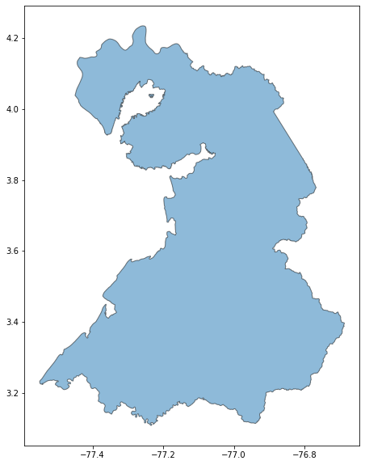

```python
# Copia del objeto bna que es el multipoligono original de buenaventura en el objeto bna2
bna2 = bna.copy()

# Divide el objeto bna2 en polígonos que conforman el multipoligono original
bna2 = bna2.explode(index_parts=False)

# Reasigna los índices del objeto bna2
bna2.index = list(range(len(bna2)))

# Muestra las primeras filas del objeto bna2
display(bna2.head())

# Imprime una línea de separación
print("-"*75)

# Grafica los polígonos del objeto bna2 con bordes negros, transparencia y tamaño de figura
bna2.plot(edgecolor="k", alpha=0.5, figsize=(10,10))

# Muestra el gráfico
plt.show()
```

La función geom.wkt se utiliza para obtener la representación Well-Known Text (WKT) de un objeto de geometría. WKT es un formato de texto utilizado para describir geometrías espaciales en un formato legible por humanos.

```python
# Agregamos un nuevo campo al conjunto de datos usando la funcion to_wkt()
bna2['wkt'] = bna2.geometry.to_wkt()
# Mostramos los datos
bna2
```

|  | Shape_Leng | Shape_Area | ADM2_ES | ADM2_PCODE | ADM2_REF | ADM2ALT1ES | ADM2ALT2ES | ADM1_ES | ADM1_PCODE | ADM0_ES | ADM0_PCODE | date | validOn | validTo | geometry | wkt |
| --- | --- | --- | --- | --- | --- | --- | --- | --- | --- | --- | --- | --- | --- | --- | --- | --- |
| 0 | 6.618278 | 0.510778 | Buenaventura | CO76109 | NaN | NaN | NaN | Valle del Cauca | CO76 | Colombia | CO | 2018-01-01 | 2020-04-16 | NaN | POLYGON ((-77.23810 4.04049, -77.23774 4.03965... | POLYGON ((-77.2381 4.040486, -77.237743 4.0396... |
| 1 | 6.618278 | 0.510778 | Buenaventura | CO76109 | NaN | NaN | NaN | Valle del Cauca | CO76 | Colombia | CO | 2018-01-01 | 2020-04-16 | NaN | POLYGON ((-77.23178 4.16680, -77.22946 4.16473... | POLYGON ((-77.231784 4.166803, -77.229465 4.16... |

Trabajar con todo el poligono puede ser algo pesado para la API del GBIF por lo cual vamos a empexar a buscar el uadrante que encierre a nuestro poligono para iniciar la busqueda.

```python
from shapely.geometry import MultiPolygon, Polygon
from shapely.ops import unary_union

a = 0.25  # Asignación del valor 0.25 a la variable 'a'
delta = 0.49  # Asignación del valor 0.49 a la variable 'delta'

P = bna2.geometry.boundary  # Obtención de los límites de la geometría en la columna 'geometry' de 'bna2' y asignación a la variable 'P'

eps = 0.01  # Asignación del valor 0.01 a la variable 'eps'

omega = unary_union([
    Polygon(component.coords).buffer(eps).buffer(-eps) for component in P
])  # Creación de un objeto geométrico 'omega' mediante la unión de los polígonos generados a partir de los componentes de 'P'
   # Cada componente se convierte en un objeto de la clase Polygon, se le aplica un buffer de tamaño 'eps' y luego otro buffer de tamaño '-eps'
   # Por último, se realiza la unión de todos estos polígonos utilizando la función unary_union
```

Estas líneas de código realizan las siguientes acciones:

- Importan el módulo 'wkt' de la biblioteca Shapely, que proporciona funciones para trabajar con el formato WKT (Well-Known Text).
- Convierten el objeto geométrico 'omega' en una cadena en formato WKT utilizando la función 'dumps' del módulo 'wkt' y la asignan a la variable 'wkt_string'.
- Dividen la cadena 'wkt_string' en una lista de subcadenas utilizando la cadena 'POLYGON ' como separador. Luego, se realiza un procesamiento adicional en cada subcadena para extraer las coordenadas de los puntos. Estas coordenadas se convierten a tipo float y se almacenan en la lista 'points'.

```python
from shapely import wkt
# Convierte el objeto geométrico 'omega' en una cadena en formato WKT y la asigna a la variable 'wkt_string'
wkt_string = wkt.dumps(omega)
# Almacenamos los puntos en una lista
points = [list(map(float, i.replace('(','').replace(')','').split(' ')[1:])) for i in wkt_string.split('POLYGON ')[1].split(',')[1:-1]]
# Mostramos el total puntos que tiene nuestra area de interes
len(points)
```

```
8109
```

## **Parte 3**: Cálculo del rectángulo mínimo

### Encontrando el rectángulo de mínima área que contiene la zona de interes

Esta función, `minimum_bounding_rectangle`, encuentra el rectángulo de mínima área que contiene un conjunto de puntos. Aquí se explica en 4 pasos lo que hace:

- Paso 1: Se calcula el casco convexo de un conjunto de puntos utilizando el algoritmo de envoltura convexa y se obtienen los puntos que forman el casco convexo.
- Paso 2: Se calculan los ángulos de los bordes del casco convexo y se generan las matrices de rotación correspondientes.
- Paso 3: Se aplica la rotación a los puntos del casco convexo.
- Paso 4: Se encuentra el rectángulo de menor área dentro del casco convexo rotado, y se obtienen las coordenadas de las esquinas del rectángulo.

```python
import numpy as np
from scipy.spatial import ConvexHull

def minimum_bounding_rectangle(points):
    """
    Encuentra el rectángulo de menor tamaño que contiene un conjunto de puntos.
    Devuelve un conjunto de puntos que representan las esquinas del rectángulo delimitador.

    :param points: una matriz nx2 de coordenadas
    :rval: una matriz nx2 de coordenadas
    """
    from scipy.ndimage.interpolation import rotate
    pi2 = np.pi/2.

    # Obtener el casco convexo para los puntos
    hull_points = points[ConvexHull(points).vertices]

    # Calcular los ángulos de los bordes
    edges = np.zeros((len(hull_points)-1, 2))
    edges = hull_points[1:] - hull_points[:-1]

    angles = np.zeros((len(edges)))
    angles = np.arctan2(edges[:, 1], edges[:, 0])

    angles = np.abs(np.mod(angles, pi2))
    angles = np.unique(angles)

    # Encontrar las matrices de rotación
    rotations = np.vstack([
        np.cos(angles),
        np.cos(angles-pi2),
        np.cos(angles+pi2),
        np.cos(angles)]).T
    rotations = rotations.reshape((-1, 2, 2))

    # Aplicar las rotaciones al casco convexo
    rot_points = np.dot(rotations, hull_points.T)

    # Encontrar los puntos límites del rectángulo
    min_x = np.nanmin(rot_points[:, 0], axis=1)
    max_x = np.nanmax(rot_points[:, 0], axis=1)
    min_y = np.nanmin(rot_points[:, 1], axis=1)
    max_y = np.nanmax(rot_points[:, 1], axis=1)

    # Encontrar el rectángulo con el mejor área
    areas = (max_x - min_x) * (max_y - min_y)
    best_idx = np.argmin(areas)

    # Obtener el rectángulo óptimo
    x1 = max_x[best_idx]
    x2 = min_x[best_idx]
    y1 = max_y[best_idx]
    y2 = min_y[best_idx]
    r = rotations[best_idx]

    rval = np.zeros((4, 2))
    rval[0] = np.dot([x1, y2], r)
    rval[1] = np.dot([x2, y2], r)
    rval[2] = np.dot([x2, y1], r)
    rval[3] = np.dot([x1, y1], r)

    return rval
```

```python
# Calcular el rectángulo de menor tamaño que contiene un conjunto de puntos
mabr = minimum_bounding_rectangle(np.array(points))

# Obtener la longitud del resultado (cantidad de puntos que forman el rectángulo)
longitud = len(mabr)
```

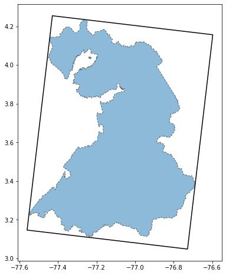

```python
# Crear un objeto de geometría a partir de los puntos del rectángulo mínimo
geometry = Polygon([[x, y] for x, y in mabr.tolist()])

# Crear un GeoDataFrame con la geometría del rectángulo y asignarle un sistema de referencia de coordenadas (crs)
sector = gpd.GeoDataFrame(data=['data'], geometry=[geometry], crs=bna2.crs)

# Crear una figura y ejes para visualización
fig, axes = plt.subplots(figsize=(8, 8))

# Dibujar el mapa base (bna2) con líneas de borde y estilo punteado
bna2.plot(edgecolor='k', linestyle="--", ax=axes, alpha=0.5)

# Dibujar el rectángulo del sector con líneas de borde gruesas y sin relleno
sector.plot(edgecolor='k', linewidth=1.5, facecolor="none", ax=axes)

# Mostrar el gráfico
plt.show()
```

### Realización de consulta en el GBIF

En este caso, estableceremos una conexión con el GBIF para llevar a cabo una consulta específica. Para ilustrar este proceso, utilizaremos las claves de los géneros $Megasoma$ y $Dynastes$, dos géneros fascinantes de escarabajos.

En este ejemplo, utilizaremos las claves numéricas de género en lugar de nombres de género para realizar una consulta más eficiente en el GBIF. Esta aproximación tiene la ventaja de acelerar el proceso de búsqueda y reduce el peso de los datos al trabajar con valores numéricos en lugar de cadenas de texto.

𝑀𝑒𝑔𝑎𝑠𝑜𝑚𝑎

[figure not shown]

𝐷𝑦𝑛𝑎𝑠𝑡𝑒𝑠

[figure not shown]

```python
%%time
# Código para realizar la consulta utilizando las claves numéricas de género en el GBIF
zone = sector.geometry.to_wkt()

# Consulta para el género Megasoma
Megasoma = occurrences.search(genusKey=1074936, limit=1000, geometry=zone)

# Consulta para el género Dynastes
Dynastes = occurrences.search(genusKey=1074497, limit=1000, geometry=zone)

print("Resultados para Dynastes:", len(Dynastes['results']))
print("Resultados para Megasoma:", len(Megasoma['results']))
```

```
Resultados para Dynastes: 0
Resultados para Megasoma: 14
CPU times: total: 78.1 ms
Wall time: 2.85 s
```

En este caso, obtenemos los resultados de la búsqueda para los géneros Megasoma y Dynastes en función de las claves numéricas de género. Utilizamos el atributo limit para especificar el número máximo de resultados que deseamos obtener. Además, especificamos la geometría de la zona de interés para limitar la consulta a esa región en particular.

Al imprimir la longitud de los resultados obtenidos para cada género, podremos obtener una idea del número de registros disponibles en el GBIF para esos géneros específicos dentro de la zona seleccionada.

Esta forma de trabajar con claves numéricas y datos geográficos nos permite aprovechar la eficiencia y ligereza de los datos numéricos en las consultas del GBIF.

```python
# Unimos los datos de las consults por cada genero
escarabajos = Dynastes['results'] + Megasoma['results']
# Convertimos los diccionarios en DataFrames
dfs = [pd.DataFrame([i]) for i in escarabajos]
# Lo concatenamos en un nuevo DataFrame
data = pd.concat(dfs, axis=0)
# Como son tantas las variables que tiene cada registro solo vamos a ver algunas de ellas
display(data[['decimalLongitude', 'decimalLatitude','elevation', 'elevationAccuracy','continent','order', 'family', 'genus','scientificName']].head())
# Generemos un resumen del total de datos existentes
data.info()
```

|  | decimalLongitude | decimalLatitude | elevation | elevationAccuracy | continent | order | family | genus | scientificName |
| --- | --- | --- | --- | --- | --- | --- | --- | --- | --- |
| 0 | -77.07824 | 3.603341 | 29.0 | 0.0 | SOUTH_AMERICA | Coleoptera | Scarabaeidae | Megasoma | Megasoma Kirby, 1825 |
| 0 | -77.07824 | 3.603341 | 29.0 | 0.0 | SOUTH_AMERICA | Coleoptera | Scarabaeidae | Megasoma | Megasoma Kirby, 1825 |
| 0 | -77.07824 | 3.603341 | 29.0 | 0.0 | SOUTH_AMERICA | Coleoptera | Scarabaeidae | Megasoma | Megasoma Kirby, 1825 |
| 0 | -77.07824 | 3.603341 | 29.0 | 0.0 | SOUTH_AMERICA | Coleoptera | Scarabaeidae | Megasoma | Megasoma Kirby, 1825 |
| 0 | -77.07824 | 3.603341 | 29.0 | 0.0 | SOUTH_AMERICA | Coleoptera | Scarabaeidae | Megasoma | Megasoma Kirby, 1825 |

```
<class 'pandas.core.frame.DataFrame'>
Int64Index: 14 entries, 0 to 0
Data columns (total 94 columns):
 #   Column                         Non-Null Count  Dtype
---  ------                         --------------  -----
 0   key                            14 non-null     int64
 1   datasetKey                     14 non-null     object
 2   publishingOrgKey               14 non-null     object
 3   installationKey                14 non-null     object
 4   publishingCountry              14 non-null     object
 5   protocol                       14 non-null     object
 6   lastCrawled                    14 non-null     object
 7   lastParsed                     14 non-null     object
 8   crawlId                        14 non-null     int64
 9   hostingOrganizationKey         14 non-null     object
```

[output cut: 86 more lines]

```python
# Vamos a hacer un geodataframe con los puntos recolectados
geometry = [Point(x,y) for x,y in data[['decimalLongitude', 'decimalLatitude']].values]
# Almacenamos los datos en una nueva variable
geo_escara = gpd.GeoDataFrame(data, geometry=geometry, crs=bna2.crs)
```

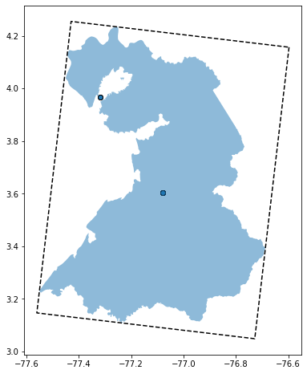

```python
# Crear una figura y ejes para visualización con tamaño de 8x8 pulgadas
fig, axes = plt.subplots(figsize=(8, 8))

# Dibujar el objeto geo_escara con líneas de borde en color negro
geo_escara.plot(edgecolor='k', ax=axes)

# Dibujar el objeto bna2 con transparencia de 0.5
bna2.plot(alpha=0.5, ax=axes)

# Dibujar el contorno (límites) del objeto sector sin relleno, con líneas punteadas en color negro
sector.boundary.plot(facecolor="none", edgecolor='k', linestyle='--', ax=axes)
# Mostramos la grafica
plt.show()
```

```python
# Vamos a identificar los puntos dentro nuestro poligono de interes
records_polygons = gpd.overlay(geo_escara,bna2)
# Vemos los registros unicos por especie
records_polygons['acceptedScientificName'].unique()
```

```
array(['Megasoma Kirby, 1825', 'Megasoma actaeon (Linnaeus, 1758)'],
      dtype=object)
```

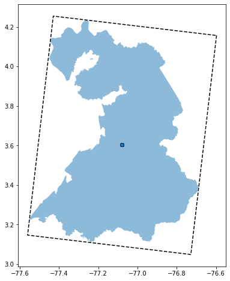

```python
# Crear una figura y ejes para visualización con tamaño de 8x8 pulgadas
fig, axes = plt.subplots(figsize=(8, 8))

# Dibujar el objeto plants_planadas con líneas de borde en color negro
records_polygons.plot(edgecolor='k', ax=axes)

# Dibujar el objeto bna2 con transparencia de 0.5
bna2.plot(alpha=0.5, ax=axes)

# Dibujar el contorno (límites) del objeto sector en color negro y estilo de línea punteada
sector.boundary.plot(color='k', linestyle='--', ax=axes)
# Mostraos el grafico
plt.show()
```

## **Parte 4**: Búsqueda de especies

### Integración y automatización de la búsqueda

Antes de continuar vamos a generar algunas funciones que haran un poco mas elegante la visualizacion de los datos y nos daran una mayor complejidad en el mapa final con el cual podremos interactuar y ver mejor la distribucion de las especies.

La función calculate_similarity compara dos nombres, selecciona las dos primeras palabras de cada nombre, y utiliza el algoritmo token_set_ratio de fuzzywuzzy para calcular el porcentaje de similitud entre ellos, devolviendo el resultado.

```python
def select_keys(dictionary, keys):
    """
    Selecciona las claves especificadas de un diccionario y devuelve un nuevo diccionario con esas claves.

    :param dictionary: el diccionario original
    :param keys: una lista de claves a seleccionar
    :return: un nuevo diccionario con las claves seleccionadas
    """
    selected_dict = dict(filter(lambda item: item[0] in keys, dictionary.items()))
    return selected_dict
```

```python
def calculate_similarity(name1, name2):
    """
    Calculate the similarity percentage between two names.

    :param name1: the first name
    :param name2: the second name
    :return: the similarity percentage between the two names
    """
    # Get the first two names and concatenate them
    trimmed_name1 = "".join(name1.split()[:2])
    trimmed_name2 = "".join(name2.split()[:2])

    # Calculate the similarity using the token_set_ratio algorithm from fuzzywuzzy
    similarity = fuzz.token_set_ratio(trimmed_name1.lower(), trimmed_name2.lower())
    return similarity
```

La función generar_colores_aleatorios crea una lista de colores aleatorios sin repetición. Utiliza una lista predefinida de colores disponibles y selecciona un número determinado de colores de manera aleatoria. Si se solicita un número mayor de colores disponibles, se completará con el color "blanco". Retorna la lista de colores generados.

```python
import random

def generar_colores_aleatorios(num_colores):
    """
    Genera una lista de colores aleatorios sin repetición.

    :param num_colores: el número de colores a generar
    :return: una lista de colores aleatorios
    """
    colores_disponibles = ['red', 'blue', 'green', 'yellow', 'orange', 'purple', 'pink', 'brown']
    colores_aleatorios = random.sample(colores_disponibles, min(num_colores, len(colores_disponibles)))
    colores_aleatorios += ['white'] * max(0, num_colores - len(colores_disponibles))
    return colores_aleatorios
```

La clase `SpeciesBoundingBox` tiene dos métodos principales:

1. El método `get_minimum_bounding_rectangle` calcula el rectángulo mínimo para un polígono dado. Divide el polígono en polígonos más pequeños, crea un objeto geométrico a partir de ellos y calcula el rectángulo mínimo. Luego, crea un GeoDataFrame con la geometría del rectángulo.
2. El método `find_species_in_quadrant` busca las especies que existen en un cuadrante específico del rectángulo mínimo. Realiza consultas a una base de datos de especies utilizando el cuadrante como área de búsqueda. Compara el nombre científico de las especies encontradas con las especies proporcionadas y guarda los datos correspondientes en un GeoDataFrame.

Si no se encuentran especies en el cuadrante, se lanza una excepción con un mensaje de error específico.

Estos métodos utilizan otras funciones auxiliares y bibliotecas como `fuzzywuzzy` y `geopandas` para realizar cálculos y manipulaciones espaciales.

```python
class SpeciesBoundingBox:
    def __init__(self, polygon, species=[]):
        """
        Inicializa la clase MinimumBoundingRectangle.

        :param polygon: un polígono representado por una lista de puntos
        :param species: una lista de especies
        """
        self.polygon = polygon
        self.species = list(species)

    def get_minimum_bounding_rectangle(self):
        """
        Calcula el rectángulo mínimo para el polígono.

        :return: una lista de puntos que representan las esquinas del rectángulo mínimo
        """
        # Divide el objeto bna2 en polígonos que conforman el multipoligono original
        polygons = self.polygon.explode(index_parts=False)

        a = 0.25  # Asignación del valor 0.25 a la variable 'a'
        delta = 0.49  # Asignación del valor 0.49 a la variable 'delta'

        P = polygons.geometry.boundary  # Obtención de los límites de la geometría en la columna 'geometry' de 'bna2' y asignación a la variable 'P'

        eps = 0.01  # Asignación del valor 0.01 a la variable 'eps'
        # Creación de un objeto geométrico 'omega' mediante la unión de los polígonos generados a partir de los componentes de 'P'
        omega = unary_union([
            Polygon(component.coords).buffer(eps).buffer(-eps) for component in P
        ])
        # Convierte el objeto geométrico 'omega' en una cadena en formato WKT y la asigna a la variable 'wkt_string'
        wkt_string = wkt.dumps(omega)
        # Almacenamos los puntos en una lista
        points = [list(map(float, i.replace('(','').replace(')','').split(' ')[1:])) for i in wkt_string.split('POLYGON ')[1].split(',')[1:-1]]
        # Convertir points en un array de NumPy
        points_array = np.array(points)
        # Calculamos el cuadrante
        minimum_bounding_rect = minimum_bounding_rectangle(points_array)
        # Crear un objeto de geometría a partir de los puntos del rectángulo mínimo
        geometry = Polygon([[x, y] for x, y in minimum_bounding_rect.tolist()])

        # Crear un GeoDataFrame con la geometría del rectángulo y asignarle un sistema de referencia de coordenadas (crs)
        sector = gpd.GeoDataFrame(data=['data'], geometry=[geometry], crs=polygons.crs)
        return sector

    def find_species_in_quadrant(self):
        """
        Busca las especies que existen en un cuadrante específico del rectángulo mínimo.

        :param quadrant: el cuadrante en el que se desea buscar las especies
        :return: una lista de especies encontradas en el cuadrante
        """
        # Lógica para buscar las especies en el cuadrante...
        species_in_quadrant = []  # Lista de especies encontradas en el cuadrante
        quadrant=self.get_minimum_bounding_rectangle()
        zone = quadrant.geometry.to_wkt()
        selected_keys = ['acceptedTaxonKey', 'acceptedScientificName', 'family', 'genus', 'decimalLongitude', 'decimalLatitude', 'elevation',
                         'continent', 'stateProvince', 'eventDate', 'geodeticDatum', 'country', 'county', 'locality','hostingOrganizationKey']
        for i in self.species:
            data = occurrences.search(q=i, limit=1000, geometry=zone)
            for j in data['results']:
                if calculate_similarity(j.get('acceptedScientificName', ''),i) == 100:
                    result_dict = select_keys(j, selected_keys)
                    species_in_quadrant.append(result_dict)
        try:
            dfs = [pd.DataFrame([i]) for i in species_in_quadrant]
            if len(dfs) == 0:
                raise Exception("El área de búsqueda no posee ningún registro de las especies solicitadas. Por favor, intenta con otras especies u otra área de interés.")
            data = pd.concat(dfs, axis=0)

            # Vamos a hacer un GeoDataFrame con los puntos recolectados
            geometry = [Point(x,y) for x,y in data[['decimalLongitude', 'decimalLatitude']].values]
            # Almacenamos los datos en una nueva variable
            geo_points = gpd.GeoDataFrame(data, geometry=geometry, crs=quadrant.crs)
            geo_points = geo_points[selected_keys+["geometry"]]
            return geo_points
        except Exception as e:
            print(str(e))
```

Carapa guianensis

[figure not shown]

Hoja: compuesta

Rango altitudinal: 0-800 m

Altura máxima: 35 m

[Fuente](https://biogeodb.stri.si.edu/bioinformatics/dfm/metas/view/20886)

Humiriastrum procerum

[figure not shown]

Hoja: simple

Rango altitudinal: 0-1200 m

Altura máxima: 50 m

[Fuente](https://biogeodb.stri.si.edu/bioinformatics/dfm/metas/view/8804)

Anacardium excelsum

[figure not shown]

Hoja: simple

Rango altitudinal: 0-1000 m

Altura máxima: 40 m

[Fuente](https://biogeodb.stri.si.edu/bioinformatics/dfm/metas/view/29379)

```python
# Elegimos el area de interes
area = municipios[municipios['ADM1_ES'] =='Valle del Cauca']
# Elegimos las especies
list_sp = ["Carapa guianensis","Humiriastrum procerum","Anacardium excelsum"]
# Insertamos los datos de entrada en nuestra clase previamente formada
test_obj = SpeciesBoundingBox(area,list_sp)
# Activamos el metodo para generar el cuadrante
recta_minum = test_obj.get_minimum_bounding_rectangle()
# Activamos el metodo para buscar las especies del cuadrante
sps = test_obj.find_species_in_quadrant()
```

```python
# Mostramos los primeros 5 registros
display(sps.head())
# Mostramos un resumen del conjunto de datos
sps.info()
```

|  | acceptedTaxonKey | acceptedScientificName | family | genus | decimalLongitude | decimalLatitude | elevation | continent | stateProvince | eventDate | geodeticDatum | country | county | locality | hostingOrganizationKey | geometry |
| --- | --- | --- | --- | --- | --- | --- | --- | --- | --- | --- | --- | --- | --- | --- | --- | --- |
| 0 | 3190513 | Carapa guianensis Aubl. | Meliaceae | Carapa | -76.994930 | 3.359870 | 186.0 | SOUTH_AMERICA | Valle del Cauca | 2017-01-01T00:00:00 | WGS84 | Colombia | Buenaventura | San Isidro | c4f66525-4d36-4c18-82ac-98e088f54db4 | POINT (-76.99493 3.35987) |
| 0 | 3190513 | Carapa guianensis Aubl. | Meliaceae | Carapa | -76.994930 | 3.359870 | 186.0 | SOUTH_AMERICA | Valle del Cauca | 2017-01-01T00:00:00 | WGS84 | Colombia | Buenaventura | San Isidro | c4f66525-4d36-4c18-82ac-98e088f54db4 | POINT (-76.99493 3.35987) |
| 0 | 3190513 | Carapa guianensis Aubl. | Meliaceae | Carapa | -76.673778 | 5.023667 | 70.0 | SOUTH_AMERICA | Chocó | 2012-05-01T00:00:00 | WGS84 | Colombia | NaN | Corregimiento Jigualito, Condoto | e1050db2-9faf-4d72-b860-295debaf9d2a | POINT (-76.67378 5.02367) |
| 0 | 3190513 | Carapa guianensis Aubl. | Meliaceae | Carapa | -76.974415 | 3.998835 | NaN | SOUTH_AMERICA | Valle del Cauca | 1961-04-25T00:00:00 | WGS84 | Colombia | NaN | Bajo Calima. | c4f66525-4d36-4c18-82ac-98e088f54db4 | POINT (-76.97441 3.99884) |
| 0 | 3190513 | Carapa guianensis Aubl. | Meliaceae | Carapa | -77.166667 | 3.933333 | NaN | SOUTH_AMERICA | NaN | 1979-11-15T00:00:00 | WGS84 | Colombia | NaN | Hab.: Departamento Valle Del Cauca: Municipio ... | 396d5f30-dea9-11db-8ab4-b8a03c50a862 | POINT (-77.16667 3.93333) |

```
<class 'geopandas.geodataframe.GeoDataFrame'>
Int64Index: 131 entries, 0 to 0
Data columns (total 16 columns):
 #   Column                  Non-Null Count  Dtype
---  ------                  --------------  -----
 0   acceptedTaxonKey        131 non-null    int64
 1   acceptedScientificName  131 non-null    object
 2   family                  131 non-null    object
 3   genus                   131 non-null    object
 4   decimalLongitude        131 non-null    float64
 5   decimalLatitude         131 non-null    float64
 6   elevation               122 non-null    float64
 7   continent               131 non-null    object
 8   stateProvince           130 non-null    object
 9   eventDate               121 non-null    object
 10  geodeticDatum           131 non-null    object
 11  country                 131 non-null    object
 12  county                  114 non-null    object
 13  locality                129 non-null    object
 14  hostingOrganizationKey  131 non-null    object
 15  geometry                131 non-null    geometry
dtypes: float64(3), geometry(1), int64(1), object(11)
memory usage: 17.4+ KB
```

```python
import folium
import random
import json
import warnings
# Desactivamos el sistema de alarmas del notebook
warnings.filterwarnings('ignore')

# Disolvemos
area = area.dissolve(by="ADM1_ES")

# Proyectar las geometrías a un CRS proyectado
area_projected = area.to_crs('EPSG:4326')  # Reemplaza 'XXXX' con el código EPSG adecuado para tu área

# Obtener el centroide del GeoDataFrame 'area_projected'
centroide = area_projected.centroid.iloc[0]

# Obtener las coordenadas de latitud y longitud del centroide
latitud = centroide.y
longitud = centroide.x

# Obtener las coordenadas de latitud y longitud del centroide
latitud = centroide.y
longitud = centroide.x

# Crear un objeto de mapa con las coordenadas del centroide y el nivel de zoom inicial
mapa = folium.Map(location=[latitud, longitud], zoom_start=8)

# Agregar el mapa base de OpenStreetMap al objeto de mapa
folium.TileLayer('openstreetmap').add_to(mapa)

# Agregar los objetos de área  al mapa como capa
folium.GeoJson(area, name=area.index[0]).add_to(mapa)

# Obtener una lista de colores aleatorios sin repetición
colores_aleatorios = generar_colores_aleatorios(len(sps["acceptedScientificName"].unique()))

# Separamos por especies de sps para agregar al mapa como capas
for n, i in enumerate(sps["acceptedScientificName"].unique()):
    sub_sp = sps[sps["acceptedScientificName"] == i].copy()
    c = colores_aleatorios[n] # Generar un color aleatorio de la lista
    # Crear un grupo de características para los puntos
    puntos_group = folium.FeatureGroup(name=i)

    # Agregar los puntos al grupo de características
    for idx, row in sub_sp.iterrows():
        folium.CircleMarker(
            location=[row['decimalLatitude'], row['decimalLongitude']],
            radius=4,
            color='black',
            fill=True,
            fill_color=c,
            fill_opacity=0.5,
            weight=1
        ).add_to(puntos_group)

    # Agregar el grupo de características al mapa
    puntos_group.add_to(mapa)

# Agregar el rectángulo mínimo al mapa como contorno en color negro y estilo de línea punteada
folium.GeoJson(
    recta_minum.boundary,
    name='Rectángulo Mínimo',
    style_function=lambda x: {'color': 'black', 'dashArray': '5, 5', 'weight': 1}
).add_to(mapa)

# Agregar un control de capas al mapa para permitir al usuario seleccionar qué capas mostrar
folium.LayerControl().add_to(mapa)

# Mostrar el mapa interactivo
mapa
```

Make this Notebook Trusted to load map: File -> Trust Notebook

[interactive chart not shown]

```python
# Activamos el sistema de alarmas del notebook
warnings.filterwarnings('default')
```

## Conclusiones

1. El GBIF resultó ser una herramienta increíblemente útil para encontrar información y datos espaciales de biodiversidad. Su amplia base de datos proveniente de diversas instituciones facilitó el acceso a una gran cantidad de información para nuestro análisis.
2. Aunque en nuestro ejercicio utilizamos divisiones administrativas para la búsqueda de datos, es importante destacar que este enfoque se puede replicar en otras áreas geográficas, como cuencas hidrográficas, distritos de riego o zonas de intervención para proyectos específicos. Las posibilidades son infinitas, lo que nos permite explorar diferentes aspectos de la biodiversidad y su distribución espacial.
3. El uso de código para este tipo de proyectos resulta extremadamente útil. La documentación paso a paso de lo que se hizo nos permite no solo entender y replicar nuestro propio trabajo, sino también mejorar la eficiencia del código. Además, abre la puerta a nuevas ideas y proyectos, ya que podemos utilizar partes de este código como base para futuras investigaciones.